# DA 101 Lec 10

Your Name

30 September, 2019

## Wake-up challenge: dplyr

We’ll use the built-in `mpg` data.

```r
mpg %>% head
```

| manufacturer | model | displ | year | cyl | trans | drv | cty | hwy | fl | class |
| --- | --- | --- | --- | --- | --- | --- | --- | --- | --- | --- |
| audi | a4 | 1.8 | 1999 | 4 | auto(l5) | f | 18 | 29 | p | compact |
| audi | a4 | 1.8 | 1999 | 4 | manual(m5) | f | 21 | 29 | p | compact |
| audi | a4 | 2.0 | 2008 | 4 | manual(m6) | f | 20 | 31 | p | compact |
| audi | a4 | 2.0 | 2008 | 4 | auto(av) | f | 21 | 30 | p | compact |
| audi | a4 | 2.8 | 1999 | 6 | auto(l5) | f | 16 | 26 | p | compact |
| audi | a4 | 2.8 | 1999 | 6 | manual(m5) | f | 18 | 26 | p | compact |

Your challenge, shgould you choose to accept it (and you will!):

1. Make a new table that shows the average mpg for each class. (Very similar to part of your lab).

Which dplyr function?

Not select, since select lets you choose variables:

```r
mpg %>% select(year)
```

| year |
| --- |
| 1999 |
| 1999 |
| 2008 |
| 2008 |
| 1999 |
| 1999 |
| 2008 |
| 1999 |
| 1999 |
| 2008 |

[output cut: 224 more lines]

Needed: `summarise()` !! But first, `group_by()`

```r
#first, group_by.  Then, summarize avg cty mpg.

mpg %>% group_by(class) %>%
        summarise(meanCityMpg = mean(cty))
```

| class | meanCityMpg |
| --- | --- |
| 2seater | 15.40000 |
| compact | 20.12766 |
| midsize | 18.75610 |
| minivan | 15.81818 |
| pickup | 13.00000 |
| subcompact | 20.37143 |
| suv | 13.50000 |

2. Add to the existing table the average mpg for each class.

Which function? `mutate()`!

```r
mpg %>% group_by(class) %>% mutate(meanCtyMpg = mean(cty))
```

| manufacturer | model | displ | year | cyl | trans | drv | cty | hwy | fl | class | meanCtyMpg |
| --- | --- | --- | --- | --- | --- | --- | --- | --- | --- | --- | --- |
| audi | a4 | 1.8 | 1999 | 4 | auto(l5) | f | 18 | 29 | p | compact | 20.12766 |
| audi | a4 | 1.8 | 1999 | 4 | manual(m5) | f | 21 | 29 | p | compact | 20.12766 |
| audi | a4 | 2.0 | 2008 | 4 | manual(m6) | f | 20 | 31 | p | compact | 20.12766 |
| audi | a4 | 2.0 | 2008 | 4 | auto(av) | f | 21 | 30 | p | compact | 20.12766 |
| audi | a4 | 2.8 | 1999 | 6 | auto(l5) | f | 16 | 26 | p | compact | 20.12766 |
| audi | a4 | 2.8 | 1999 | 6 | manual(m5) | f | 18 | 26 | p | compact | 20.12766 |
| audi | a4 | 3.1 | 2008 | 6 | auto(av) | f | 18 | 27 | p | compact | 20.12766 |
| audi | a4 quattro | 1.8 | 1999 | 4 | manual(m5) | 4 | 18 | 26 | p | compact | 20.12766 |
| audi | a4 quattro | 1.8 | 1999 | 4 | auto(l5) | 4 | 16 | 25 | p | compact | 20.12766 |
| audi | a4 quattro | 2.0 | 2008 | 4 | manual(m6) | 4 | 20 | 28 | p | compact | 20.12766 |

[output cut: 224 more lines]

## CLT Demo with simulations: `sample` and `replicate`

Simulations are awesome! They let us perform experiments with just our computers. They can’t tell us everything, but they’re helpful for investigations.

First, let’s look at sample:

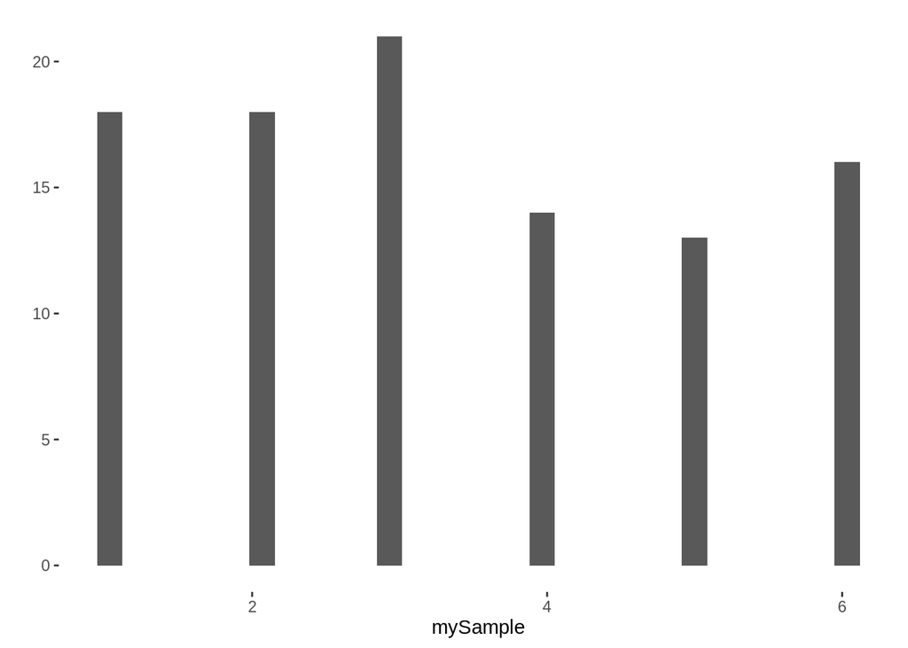

```r
#demo of sample() for dice experiment

mySample <- sample(1:6, 100, replace = TRUE)

#let's look:

qplot(mySample, geom="histogram")
```

Seems reasonable; we expect 1, 2, 3, 4, 5, 6 to be equal, but we know there’s random variation.

Challenge: plot a histo for a sample of size 5000

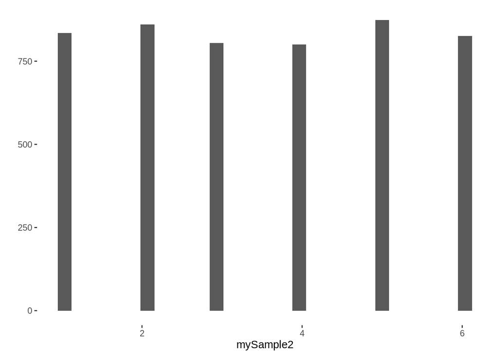

```r
mySample2 <- sample(1:6, 5000, replace = TRUE)

qplot(mySample2, geom="histogram")
```

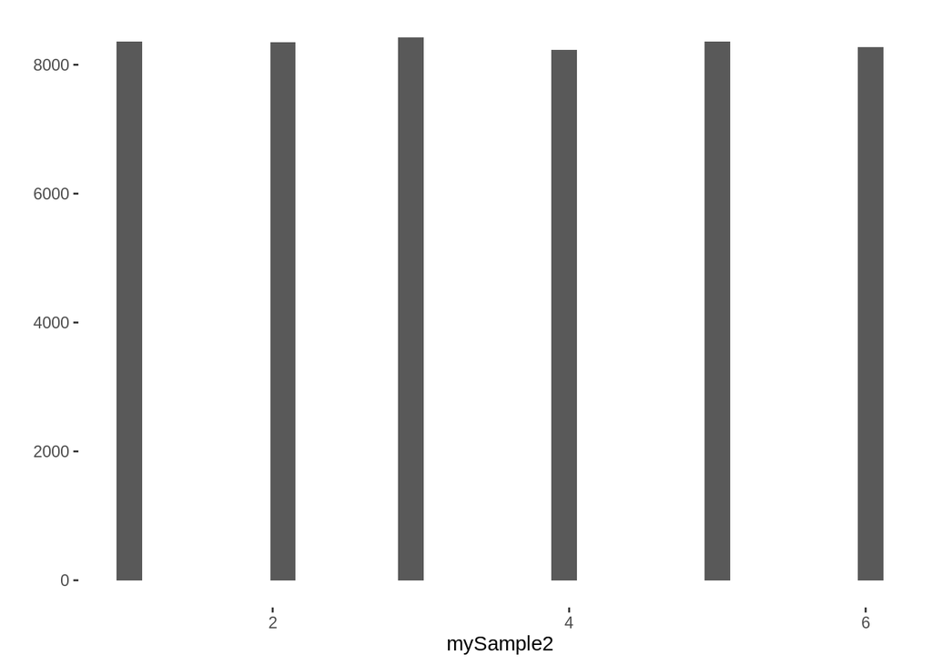

```r
mySample2 <- sample(1:6, 50000, replace = TRUE)

qplot(mySample2, geom="histogram")
```

Conclusion: as sample size increases, the proportions get closer and closer to the expected 1/6.

**Example with means**

Let’s replicate the full experiment: 100 samples of size 34

Use `replicate()`.

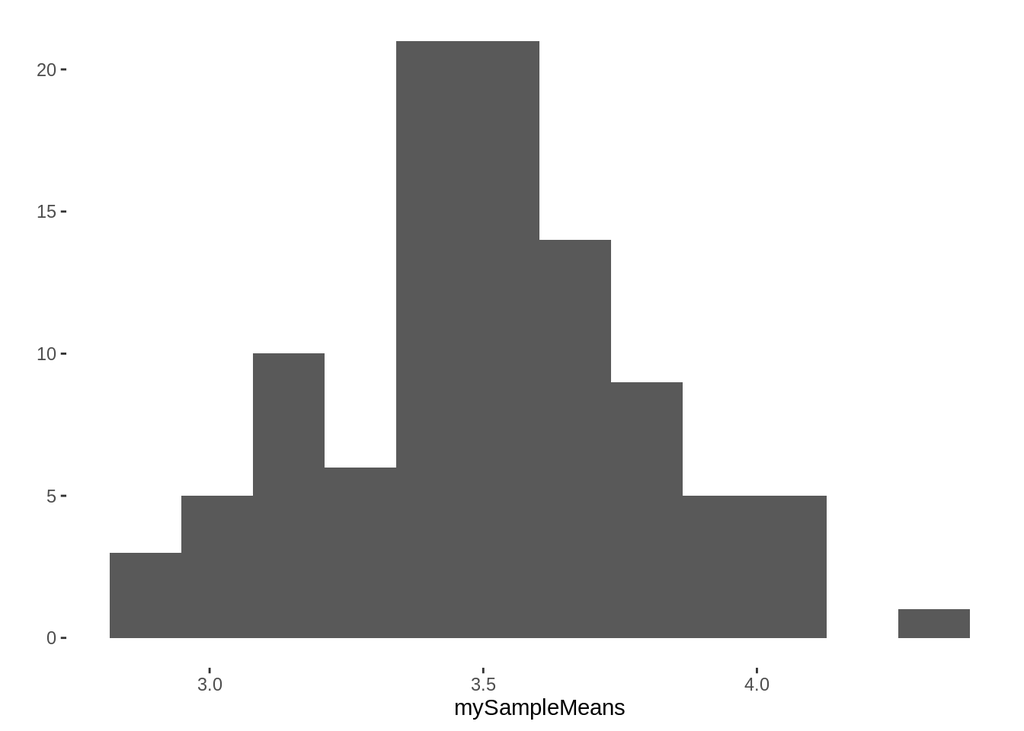

```r
mySampleMeans <- replicate(100, mean(sample(1:6, 34, replace = TRUE)))

#let's look:

qplot(mySampleMeans, geom="histogram", bins=12)
```

Observation: even with a relatively low sample size (n=34) and not too many samples (100), we all can see the pattern. Sample means follow a normal distribution. Bigger n, closer to normal (bell curve).

Let’s bump up: 5000 samples of size 1000

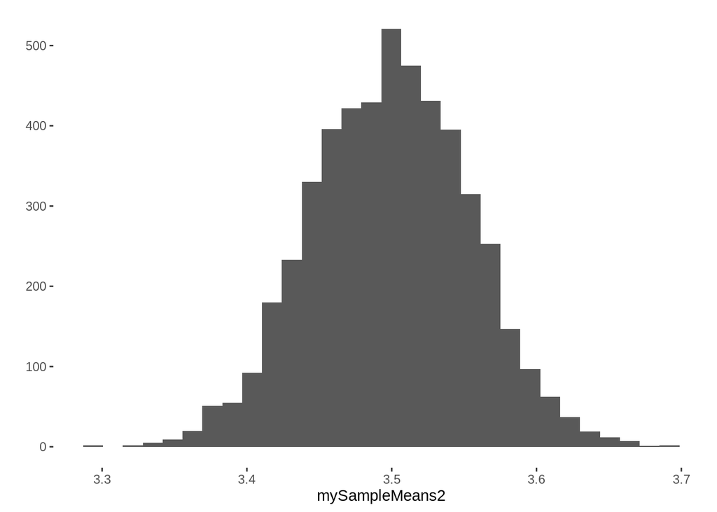

```r
mySampleMeans2 <- replicate(5000, mean(sample(1:6, 1000, replace = TRUE)))

#let's look:

qplot(mySampleMeans2, geom="histogram", bins=30)
```

Woooooah! For large samples, we see that the means follow a normal/bell curve distribution. Amazing fact: THIS ALWAYS HAPPENS!!! THE CENTRAL LIMIT THEOREM (CLT)!!!!!

No matter what our original population is, even if it’s a super weird crazy non-normal population, sample means (with large n) **always** follow a normal dist.

This fact is the reason that we can find p-vals, since sample means are **very predictable**.

Here’s how p-vals work:

1. We make an assumption about the population (H0). That value is the **center of our bell curve**

p is the probability of observing a sample result as or more extreme than the one we got.

In other words: We know that the means follow a bell curve (normal). We must make an assumption about the center (H0), and then, find the area out past our test stat.

TAIL AREA = PVAL!!!!!

If your test stat is waaaaay out in the tails, then our ovbserved data is unlikely according to the null hyp. We trust our data, so we reject H0.

## Left-tail, right-tail, two-tail

There are three possibilities for Ha.

H0 is *always* a statement of equality (=)

Ha depends on what we want to show:

- Ha: mu1 > mu2 (right tail test)
- Ha: mu1 < mu2 (left tail test)
- Ha: mu1 != mu2

## Examples: `mpg` data